# Supply Chain Analysis of Retail Store

Kanishk Kapoor

#Importing and preparing dataset

```r
library(tidyverse)
library(lubridate)
library(forecast)
```

```r
library(dplyr)
library(ggplot2)
library(caret)
library(scales)
library(zoo)
library(ompr)
library(ompr.roi)
library(ROI.plugin.glpk)
library(reshape2)
setwd("C:/Users/DELL/Desktop/SCOA")
mainData <- read.csv("supply_chain_data.csv")
```

#Data Brief

```r
head(mainData)
```

|  | Product.type | SKU | Price | Availability | Number.of.products.sold | Revenue.generated | Customer.demographics | Stock.levels | Lead.times | Order.quantities | Shipping.times | Shipping.carriers | Shipping.costs | Supplier.name | Location | Lead.time | Production.volumes | Manufacturing.lead.time | Manufacturing.costs | Inspection.results | Defect.rates | Transportation.modes | Routes | Costs |
| --- | --- | --- | --- | --- | --- | --- | --- | --- | --- | --- | --- | --- | --- | --- | --- | --- | --- | --- | --- | --- | --- | --- | --- | --- |
| 1 | haircare | SKU0 | 69.808006 | 55 | 802 | 8661.997 | Non-binary | 58 | 7 | 96 | 4 | Carrier B | 2.956572 | Supplier 3 | Mumbai | 29 | 215 | 29 | 46.27988 | Pending | 0.2264104 | Road | Route B | 187.7521 |
| 2 | skincare | SKU1 | 14.843523 | 95 | 736 | 7460.900 | Female | 53 | 30 | 37 | 2 | Carrier A | 9.716575 | Supplier 3 | Mumbai | 23 | 517 | 30 | 33.61677 | Pending | 4.8540680 | Road | Route B | 503.0656 |
| 3 | haircare | SKU2 | 11.319683 | 34 | 8 | 9577.750 | Unknown | 1 | 10 | 88 | 2 | Carrier B | 8.054479 | Supplier 1 | Mumbai | 12 | 971 | 27 | 30.68802 | Pending | 4.5805926 | Air | Route C | 141.9203 |
| 4 | skincare | SKU3 | 61.163343 | 68 | 83 | 7766.836 | Non-binary | 23 | 13 | 59 | 6 | Carrier C | 1.729569 | Supplier 5 | Kolkata | 24 | 937 | 18 | 35.62474 | Fail | 4.7466486 | Rail | Route A | 254.7762 |
| 5 | skincare | SKU4 | 4.805496 | 26 | 871 | 2686.505 | Non-binary | 5 | 3 | 56 | 8 | Carrier A | 3.890548 | Supplier 1 | Delhi | 5 | 414 | 3 | 92.06516 | Fail | 3.1455795 | Air | Route A | 923.4406 |
| 6 | haircare | SKU5 | 1.699976 | 87 | 147 | 2828.349 | Non-binary | 90 | 27 | 66 | 3 | Carrier B | 4.444099 | Supplier 4 | Bangalore | 10 | 104 | 17 | 56.76648 | Fail | 2.7791935 | Road | Route A | 235.4612 |

```r
summary(mainData)
```

```
##  Product.type           SKU                Price        Availability
##  Length:100         Length:100         Min.   : 1.70   Min.   :  1.00
##  Class :character   Class :character   1st Qu.:19.60   1st Qu.: 22.75
##  Mode  :character   Mode  :character   Median :51.24   Median : 43.50
##                                        Mean   :49.46   Mean   : 48.40
##                                        3rd Qu.:77.20   3rd Qu.: 75.00
##                                        Max.   :99.17   Max.   :100.00
##  Number.of.products.sold Revenue.generated Customer.demographics
##  Min.   :  8.0           Min.   :1062      Length:100
##  1st Qu.:184.2           1st Qu.:2813      Class :character
##  Median :392.5           Median :6006      Mode  :character
##  Mean   :461.0           Mean   :5776
##  3rd Qu.:704.2           3rd Qu.:8254
##  Max.   :996.0           Max.   :9866
##   Stock.levels      Lead.times    Order.quantities Shipping.times
##  Min.   :  0.00   Min.   : 1.00   Min.   : 1.00    Min.   : 1.00
##  1st Qu.: 16.75   1st Qu.: 8.00   1st Qu.:26.00    1st Qu.: 3.75
##  Median : 47.50   Median :17.00   Median :52.00    Median : 6.00
##  Mean   : 47.77   Mean   :15.96   Mean   :49.22    Mean   : 5.75
##  3rd Qu.: 73.00   3rd Qu.:24.00   3rd Qu.:71.25    3rd Qu.: 8.00
##  Max.   :100.00   Max.   :30.00   Max.   :96.00    Max.   :10.00
##  Shipping.carriers  Shipping.costs  Supplier.name        Location
##  Length:100         Min.   :1.013   Length:100         Length:100
##  Class :character   1st Qu.:3.540   Class :character   Class :character
##  Mode  :character   Median :5.321   Mode  :character   Mode  :character
##                     Mean   :5.548
##                     3rd Qu.:7.602
##                     Max.   :9.930
##    Lead.time     Production.volumes Manufacturing.lead.time Manufacturing.costs
##  Min.   : 1.00   Min.   :104.0      Min.   : 1.00           Min.   : 1.085
##  1st Qu.:10.00   1st Qu.:352.0      1st Qu.: 7.00           1st Qu.:22.983
##  Median :18.00   Median :568.5      Median :14.00           Median :45.906
##  Mean   :17.08   Mean   :567.8      Mean   :14.77           Mean   :47.267
##  3rd Qu.:25.00   3rd Qu.:797.0      3rd Qu.:23.00           3rd Qu.:68.621
##  Max.   :30.00   Max.   :985.0      Max.   :30.00           Max.   :99.466
##  Inspection.results  Defect.rates     Transportation.modes    Routes
##  Length:100         Min.   :0.01861   Length:100           Length:100
##  Class :character   1st Qu.:1.00965   Class :character     Class :character
##  Mode  :character   Median :2.14186   Mode  :character     Mode  :character
##                     Mean   :2.27716
##                     3rd Qu.:3.56399
##                     Max.   :4.93926
##      Costs
##  Min.   :103.9
##  1st Qu.:318.8
##  Median :520.4
##  Mean   :529.2
##  3rd Qu.:763.1
##  Max.   :997.4
```

```r
view(mainData)
```

#Cleaning and Finding out data inconsistencies

```r
sum(is.na(mainData))
```

```
## [1] 0
```

#Conversion of columns to factors

```r
mainData$Product.type <- as.factor(mainData$Product.type)
mainData$Customer.demographics <- as.factor(mainData$Customer.demographics)
mainData$Location <- as.factor(mainData$Location)
mainData$Supplier.name <- as.factor(mainData$Supplier.name)
mainData$Shipping.carriers <- as.factor(mainData$Shipping.carriers)
mainData$Transportation.modes <- as.factor(mainData$Transportation.modes)
mainData$Routes <- as.factor(mainData$Routes)
```

#Exploratory Data Analysis ##Number of Products sold by product type

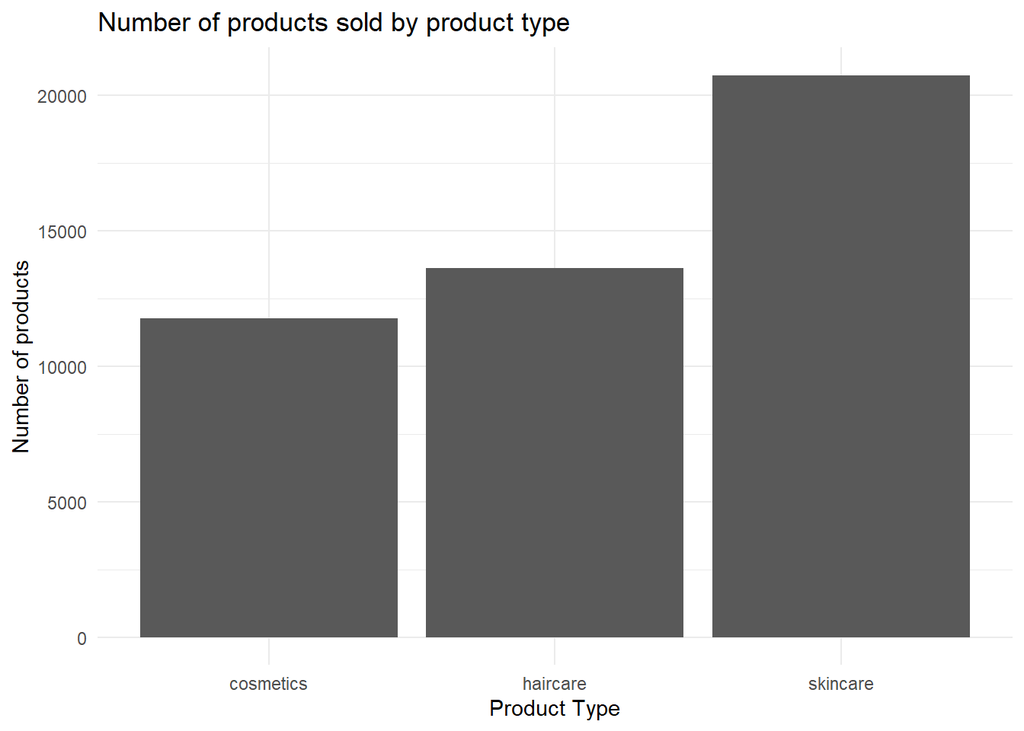

```r
ggplot(mainData,aes(x=Product.type, y=Number.of.products.sold)) + geom_bar(stat = "identity") + theme_minimal() + labs(title="Number of products sold by product type", x="Product Type", y= "Number of products")
```

###Most sold cateogry: SKINCARE

##Revenue Generated by Product Type

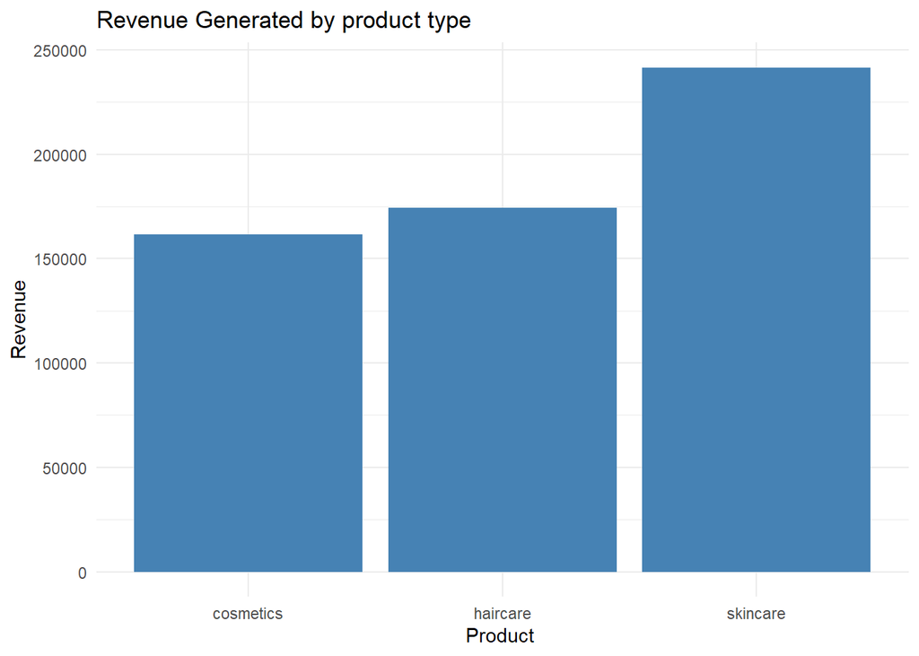

```r
ggplot(mainData,aes(x=Product.type, y=Revenue.generated)) + geom_bar(stat = "identity", fill="steelblue") + theme_minimal() + labs(title="Revenue Generated by product type", x="Product ", y= "Revenue")
```

###MOST REVENUE GENERATING CATEGORY: skincare

##Number of Products Sold by Customer Demographics

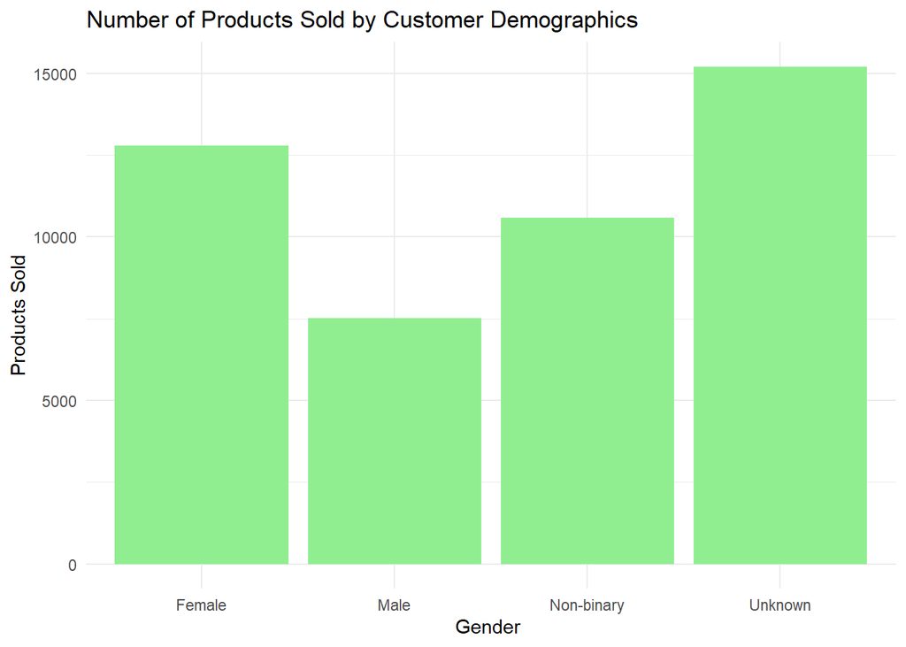

```r
ggplot(mainData,aes(x=Customer.demographics, y=Number.of.products.sold)) + geom_bar(stat = "identity", fill="lightgreen") + theme_minimal() + labs(title="Number of Products Sold by Customer Demographics", x="Gender ", y= "Products Sold")
```

###Most Products bought by : Unknown Category

## Revenue Generated vs. Number of Products Sold

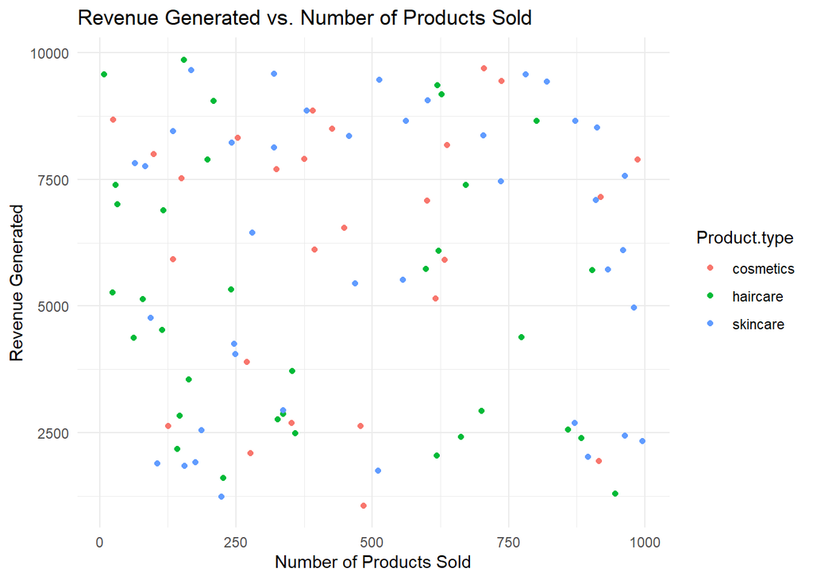

```r
ggplot(mainData, aes(x = Number.of.products.sold, y = Revenue.generated,color=Product.type)) +
  geom_point() +
  theme_minimal() +
  labs(title = "Revenue Generated vs. Number of Products Sold", x = "Number of Products Sold", y = "Revenue Generated")
```

##Price vs. Number of Products Sold

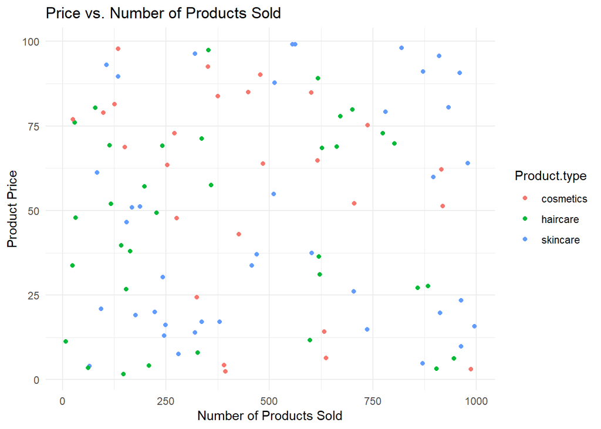

```r
ggplot(mainData, aes(x = Number.of.products.sold, y = Price,color=Product.type)) +
  geom_point() +
  theme_minimal() +
  labs(title = "Price vs. Number of Products Sold", x = "Number of Products Sold", y = "Product Price")
```

##Lead Times vs Routes

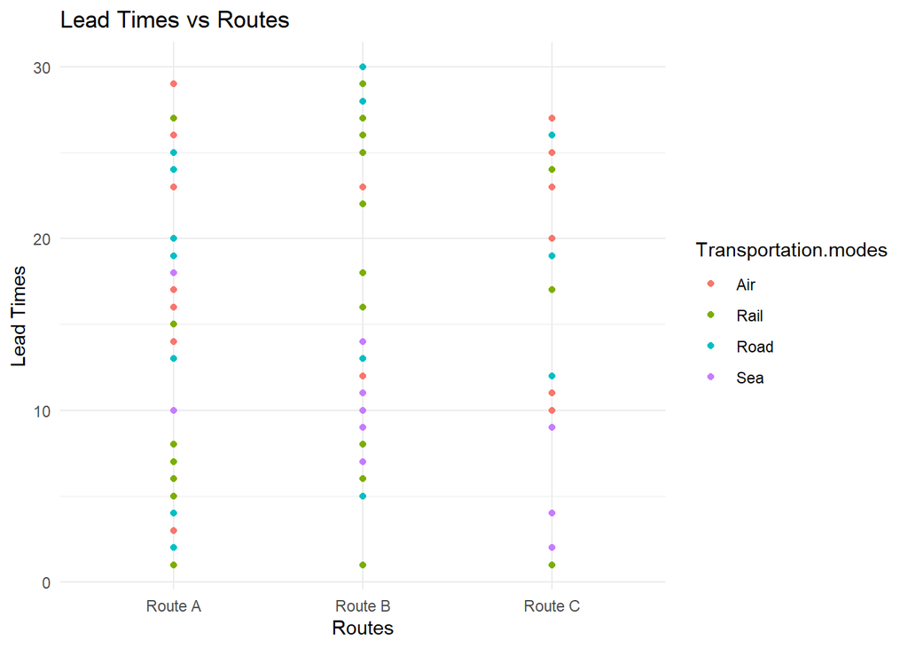

```r
ggplot(mainData, aes(x = Routes, y = Lead.times,color=Transportation.modes)) +
  geom_point() +
  theme_minimal() +
  labs(title = "Lead Times vs Routes", x = "Routes", y = "Lead Times")
```

##Distribution of Revenue Generated by Product Type

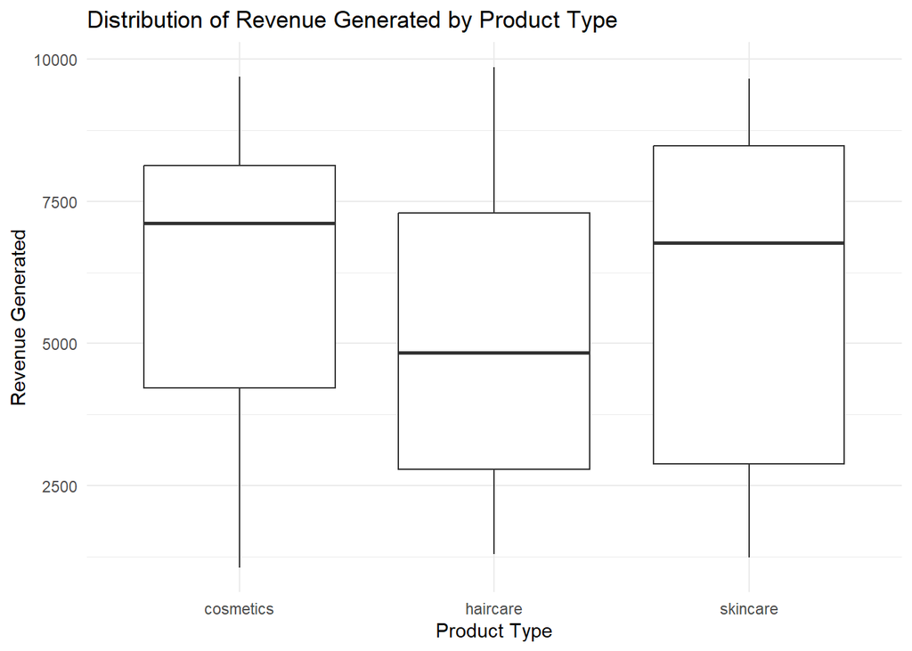

```r
ggplot(mainData, aes(x = Product.type, y = Revenue.generated)) +
  geom_boxplot() +
  theme_minimal() +
  labs(title = "Distribution of Revenue Generated by Product Type", x = "Product Type", y = "Revenue Generated")
```

##Distribution of Lead Times by Supplier

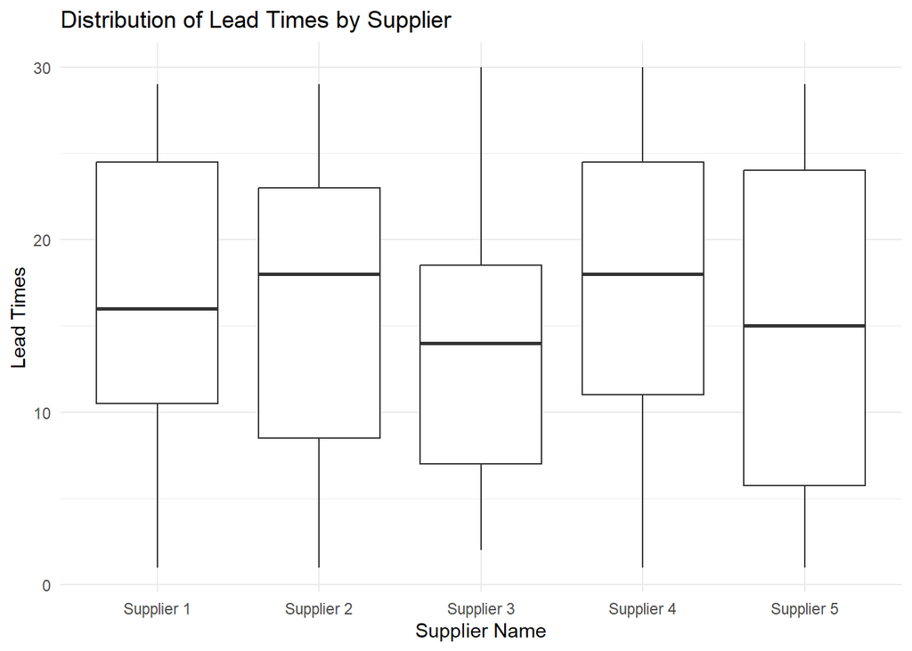

```r
ggplot(mainData, aes(x = Supplier.name, y = Lead.times)) +
  geom_boxplot() +
  theme_minimal() +
  labs(title = "Distribution of Lead Times by Supplier", x = "Supplier Name", y = "Lead Times")
```

##Correlation Heatmap

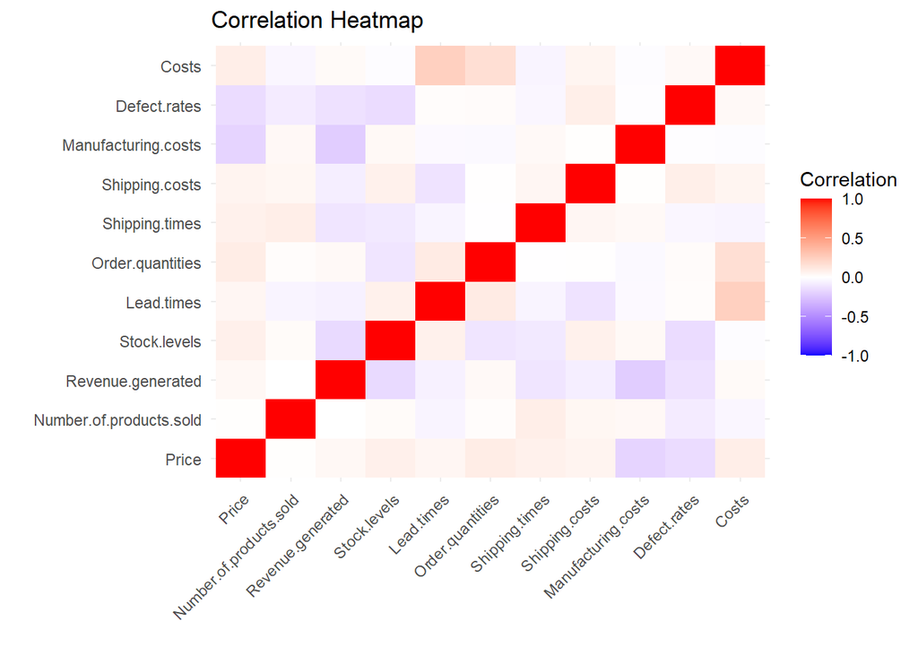

```r
library(reshape2)
numeric_data <- mainData %>% select(Price, Number.of.products.sold, Revenue.generated, Stock.levels, Lead.times, Order.quantities, Shipping.times, Shipping.costs, Manufacturing.costs, Defect.rates, Costs)
cor_data <- cor(numeric_data, use = "complete.obs")
melted_cor_data <- melt(cor_data)

ggplot(melted_cor_data, aes(x = Var1, y = Var2, fill = value)) +
  geom_tile() +
  theme_minimal() +
  labs(title = "Correlation Heatmap", x = "", y = "") +
  scale_fill_gradient2(low = "blue", high = "red", mid = "white", midpoint = 0, limit = c(-1, 1), space = "Lab", name = "Correlation")+
  theme(axis.text.x = element_text(angle = 45, hjust = 1))
```

#Feature Engineering ##Profit Margin as Percentage

```r
mainData$Profit.Margin <- (mainData$Revenue.generated - mainData$Costs) / mainData$Revenue.generated * 100
```

##Order Value: Calculate the average order value

```r
mainData$Average.Order.Value <- (mainData$Revenue.generated ) / mainData$Order.quantities
```

##Revenue per Product: Calculate revenue generated per product.

```r
mainData$Revenue.Per.Product <- mainData$Revenue.generated / mainData$Number.of.products.sold
```

##Shipping Cost per Unit: Calculate the shipping cost per unit sold.

```r
mainData$Shipping.Cost.Per.Unit <- mainData$Shipping.costs / mainData$Number.of.products.sold
```

##Defect Rate Category: Categorize defect rates into bins.

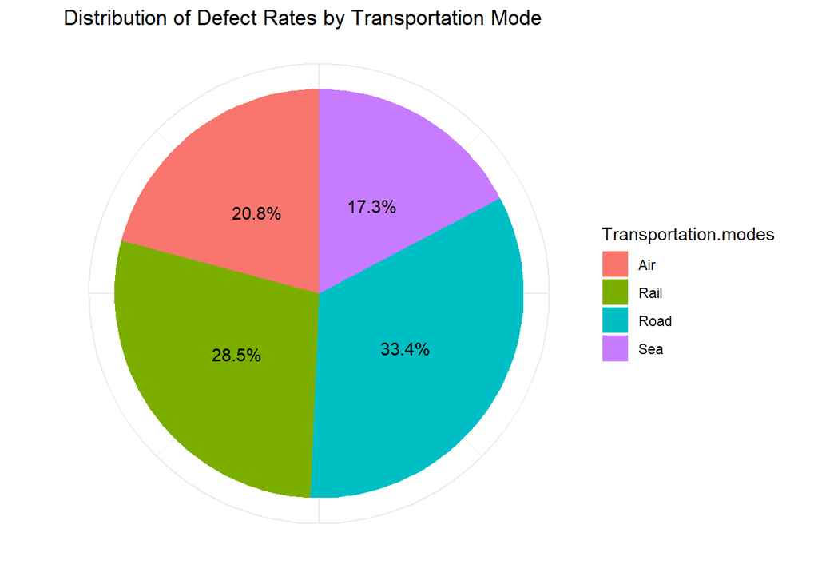

```r
mainData$Defect.Rate.Category <- cut(mainData$Defect.rates, breaks = c(-Inf, 0.01, 0.05, 0.1, Inf), labels = c("Very Low", "Low", "Moderate", "High"))

summary_data <- mainData %>%
  group_by(Transportation.modes) %>%
  summarize(total_defects = sum(Defect.rates, na.rm = TRUE))

# Calculate percentages
summary_data <- summary_data %>%
  mutate(percentage = total_defects / sum(total_defects) * 100)

# Ensure the Transportation.modes column is a factor for ordering
summary_data$Transportation.modes <- factor(summary_data$Transportation.modes)
# Create the pie chart
ggplot(summary_data, aes(x = "", y = percentage, fill = Transportation.modes)) +
  geom_bar(width = 1, stat = "identity") +
  coord_polar("y", start = 0) +
  theme_minimal() +
  labs(title = "Distribution of Defect Rates by Transportation Mode", x = "", y = "") +
  theme(axis.text.x = element_blank(), axis.ticks = element_blank()) +
  geom_text(aes(label = paste0(round(percentage, 1), "%")), position = position_stack(vjust = 0.5))
```

###HIGHER DEFECT RATES WHEN SHIPPED THROUGH ROADS

##Total Revenue by location

```r
revenue_by_location <- mainData %>% group_by(Location) %>% summarise(Total.revenue = sum(Revenue.generated, na.rm = TRUE))

revenue_by_location
```

| Location | Total.revenue |
| --- | --- |
| Bangalore | 102601.7 |
| Chennai | 119142.8 |
| Delhi | 81027.7 |
| Kolkata | 137077.6 |
| Mumbai | 137755.0 |

###MUMBAI GENERATES THE MOST REVENUE ## Average Lead Time by Supplier

```r
average_lead_time_by_supplier <- mainData %>% group_by(Supplier.name) %>% summarise(Average.Lead.Time = mean(Lead.times, na.rm = TRUE))

average_lead_time_by_supplier
```

| Supplier.name | Average.Lead.Time |
| --- | --- |
| Supplier 1 | 16.77778 |
| Supplier 2 | 16.22727 |
| Supplier 3 | 14.33333 |
| Supplier 4 | 17.00000 |
| Supplier 5 | 14.72222 |

#COST AND ROUTE Optimization Analysis ##CARRIER VS REVENUE

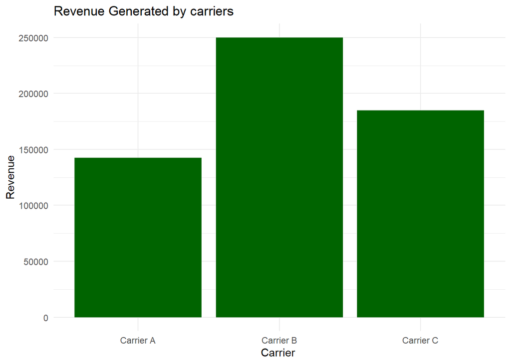

```r
ggplot(mainData,aes(x=Shipping.carriers, y=Revenue.generated)) + geom_bar(stat = "identity", fill="darkgreen") + theme_minimal() + labs(title="Revenue Generated by carriers", x="Carrier ", y= "Revenue")
```

###Carrier B generates the most revenue for the company.

##Order Quantities by SKU

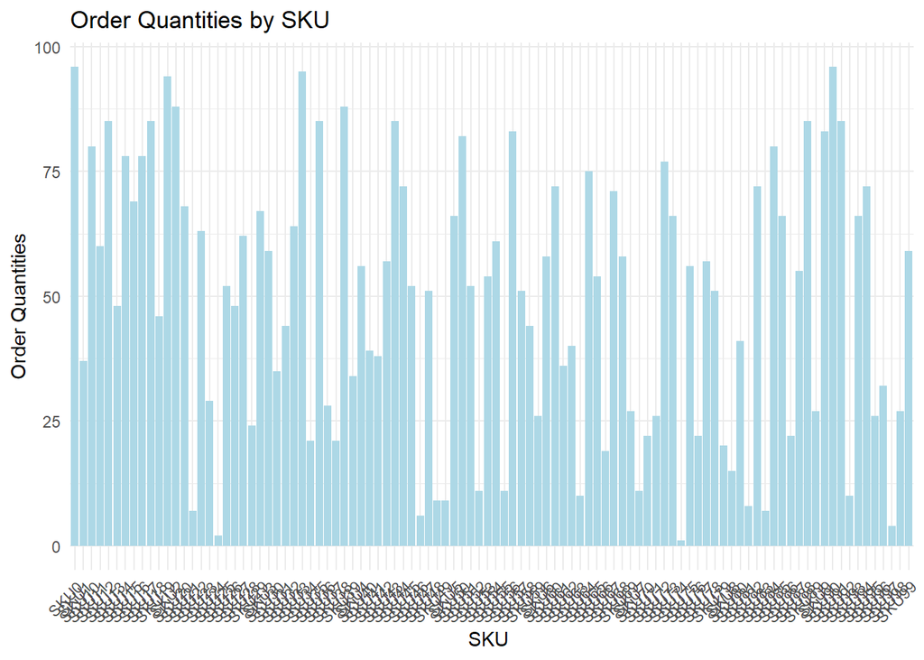

```r
ggplot(mainData,aes(x=SKU, y=Order.quantities)) + geom_bar(stat = "identity", fill="lightblue") + theme_minimal() + labs(title="Order Quantities by SKU", x="SKU ", y= "Order Quantities")+
  theme(axis.text.x = element_text(angle = 45, hjust = 1))
```